## Análisis de datos de Affymetrix HGU133A-Plus2

### Índice de contenido

1. Read the input phenoData
2. Download and read the CEL files
3. Normalize and Quality Control
4. Principal Component Analysis

#### Analysis using the genes

**Author:**  
Felipe de Jesús Muñoz González  
Instituto Nacional de Medicina Genomica (INMEGEN)  
México City, January 2016.

#### Load libraries

```r
if(!require(GEOquery)){
  source('http://bioconductor.org/biocLite.R')
  biocLite(c('GEOquery'))
}

library(GEOquery, quietly = TRUE)

# Create a list of all raw data files and assign cell lines and condition
if(!require(affy)){
  source('http://bioconductor.org/biocLite.R')
  biocLite(c('affy'))
}
library(affy, quietly = TRUE)


#Preprocessing and analysis for single microarrays and microarray batches. It asumes that the distribution between each microarray will be the same
if(!require(frma)){
  source('http://bioconductor.org/biocLite.R')
  biocLite(c('frma'))
}
library(frma, quietly = TRUE)

#This package generates microarray quality metrics reports for data in Bioconductor microarray data containers (ExpressionSet, NChannelSet, AffyBatch). One and two color array platforms are supported.
if(!require(arrayQualityMetrics)){
  source('http://bioconductor.org/biocLite.R')
  biocLite(c('arrayQualityMetrics'))
}
library(arrayQualityMetrics, quietly = TRUE)


if(!require(hgu133a.db)){
  source('http://bioconductor.org/biocLite.R')
  biocLite(c('hgu133a.db'))
}
library(hgu133a.db, quietly = TRUE)


if(!require(genefilter)){
  source('http://bioconductor.org/biocLite.R')
  biocLite(c('genefilter'))
}
library(genefilter, quietly = TRUE)


if(!require(limma)){
  source('http://bioconductor.org/biocLite.R')
  biocLite(c('limma'))
}
library(limma, quietly = TRUE)

if(!require(gplots)){
  source('http://bioconductor.org/biocLite.R')
  biocLite(c('gplots'))
}
library(gplots, quietly = TRUE)

if(!require(hgu133afrmavecs)){
  source('http://bioconductor.org/biocLite.R')
  biocLite(c('hgu133afrmavecs'))
}
library(hgu133afrmavecs, quietly = TRUE)
```

#### Read the PhenoData file

```r
phenodata<-read.csv("phenodata_HGU133A.tsv",sep="\t", header=TRUE);
rownames(phenodata)<-phenodata$rownames;
phenodata<-phenodata[-1];

#we remove all the samples that are less than 3
phenodata<-phenodata[-which(phenodata$samples %in% names(which(table(phenodata$samples)<3))),]

if(!dir.exists("Data")){
    dir.create("Data");
}

geoIDs<-as.character(rownames(phenodata))
```

#### Download and read the CEL files

We use the phenodata rownames to download the data files for samples that don’t exist yet

R code:

```r
already_there <- dir.exists(paste0("Data/",geoIDs ))

file_info <- lapply(geoIDs[!already_there], getGEOSuppFiles, baseDir="Data")

celfiles <- list.files("Data/",recursive=T, pattern="CEL.gz",ignore.case=T)
names(celfiles) <- list.files("Data/");
raw_data <- ReadAffy(filenames=paste("Data",celfiles,sep="/"), compress=T)
pData(raw_data) <- phenodata[,c(1,4,5)]
```

#### Normalize and Quality Control

This part will be done as is need it, we have to ensure that all our samples pass the quality control metrics, in order to do it is necesary to remove from the celfiles variable

```r
#Remove samples that doesn't achive the quality control
remove<-c("GSM23372","GSM246423","GSM247662","GSM247857","GSM247655", "GSM247660","GSM247656","GSM246485","GSM247650","GSM246422","GSM247663", "GSM247654", "GSM247877", "GSM656387")
```

```r
if(length(remove)>0){
  raw_rm<-raw_data[,!(sampleNames(raw_data) %in% remove)]
  eset <- frma(raw_rm)
}else{
  eset <- frma(raw_data)
}
#if(length(remove)>0){
#  raw_cells_rm<-raw_cells[,!(sampleNames(raw_cells) %in% remove_cells)]
#  eset_cells <- frma(raw_cells_rm)
#}else{
#  eset_cells <- frma(raw_cells)

#}
```

```r
#we get the new phenodata variable
phenodata<-data.frame(pData(eset))
phenodata<-droplevels(phenodata)
pData(eset)<-phenodata

#phenodata<-data.frame(pData(eset_cells))
#phenodata<-droplevels(phenodata)
#pData(eset_cells)<-phenodata
#pData(eset_cells)
#eset<-eset_cells
```

We use the arrayQualityMetrics to check the microarray quality

```r
#For errors in two packages httr and getGEO we have to remove it
# use search() and detach()

#We have to overwrite the function length.path
length.path <- function(x) length(unclass(x))

arrayQualityMetrics(expressionset=eset, outdir = "HGU133A_QualityMetrics",intgroup="samples", force = TRUE, do.logtransform = FALSE)
```

```
## The report will be written into directory 'HGU133A_QualityMetrics'.
```

[output not shown]

[output cut: 220 more lines]

[output not shown]

```r
phenodata<-pData(eset)
mean_max <- findLargest(rownames(eset), rowMeans(exprs(eset)),"hgu133a")

gset <- eset[mean_max, ]
pData(gset)<-pData(eset)
rownames(gset)<-as.character(hgu133aENTREZID)[mean_max]



barcoded<-barcode(eset, platform="GPL96")
gset_barcoded<-barcoded[mean_max,]
colnames(gset_barcoded)<-pData(eset)$samples
rownames(gset_barcoded)<-as.character(hgu133aENTREZID)[mean_max]
```

```r
write.table(exprs(gset), file = "Exprs_normalized_biopsys_hgu133A.tsv", append = FALSE, quote = TRUE, sep = "\t", eol = "\n", na = "NA", dec = ".", row.names = TRUE, col.names = TRUE, qmethod = c("escape", "double"),fileEncoding = "" )
```

#### Principal Component Analysis

Once we have our data set that passes the Quality Control we will analize it in order to understand the important parts.

First we use the Principal Component Analysis in order to see the distribution of our samples and if them are separated as samples says. [Principal Component Analysis 4 Dummies](https://georgemdallas.wordpress.com/2013/10/30/principal-component-analysis-4-dummies-eigenvectors-eigenvalues-and-dimension-reduction/)

```r
#First we define a function that stablish the max and min limits of a vector and round it
#STABLISH THE LIMITS OF A VECTOR
getlimits<-function(vector){
    min=min(vector);
    max=max(vector);
    limit=c();
    if(min<0){
        limit=c(limit,round(min-.5));
    }else{
        limit=c(limit,round(min+.5));
    }

    if(max<0){
        limit=c(limit,round(max-.5));
    }else{
        limit=c(limit,round(max+.5));
    }
}
```

*Using the Probs*

```r
if(!require(ggfortify)){
  install.packages("ggfortify")
}

library(ggfortify)

#calculate the PCA
pca = prcomp(t(exprs(eset)))

#get the principal component proportion of variability of our samples
percentil=cumsum(pca$sdev^2 / sum(pca$sdev^2))

for(i in length(percentil):2){
    percentil[i]=percentil[i]-percentil[i-1]
}

percentil=round(percentil*10000)/100



#We get the sample names
interested<-unique(phenodata$samples)

#calculate the limits of the plot based in the first and second component of the PCA
xlims=c(round(min(pca$x[,1])/100)*100, round(max(pca$x[,1])/100)*100)
ylims=c( round(min(pca$x[,2])/100)*100, round(max(pca$x[,2])/100)*100)

#get the lower and upper bounds of the plot
xlims=getlimits(pca$x[,1])
ylims=getlimits(pca$x[,2])
ylims=c(ylims[1]-10,ylims[2])

#Set the colors of each sample you can also select your own colors
colors<-rainbow(length(interested))

ylims
```

```
## [1] -68  89
```

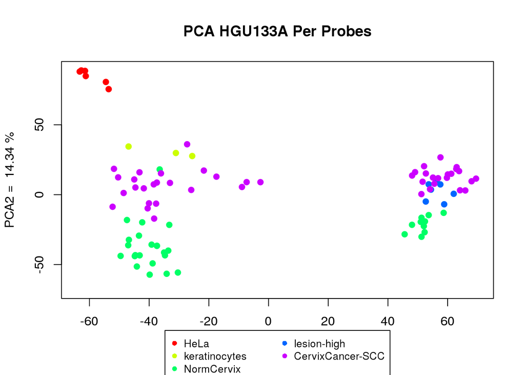

```r
#Plot the PCA and set the main title and labels
par(xpd=TRUE)
plot(NULL, main="PCA HGU133A Per Probes", xlab=paste("PCA1 = ", as.character(percentil[1]),"%"), ylab=paste("PCA2 = ", as.character(percentil[2]),"%"), xlim=xlims, ylim=ylims)

for(i in 1:length(interested)){
        datalist<-which(phenodata$samples %in% interested[i]);
        points(pca$x[datalist,1],pca$x[datalist,2], col=colors[i], pch=20, cex = 1.5)
}

legend("bottom",inset=c(0,-0.35),legend=interested, col=colors, pch=16, bg="#FFFFFF", ncol=2,cex=.85)
```

```r
#save the plot in two formats svg and pdf
dev.print(svg,"pca_per_probes.svg")
```

```r
dev.print(pdf,"pca_per_probes.pdf")
```

```r
library(ggfortify)

#calculate the PCA
pca = prcomp(t(exprs(gset)))

#get the principal component proportion of variability of our samples
percentil=cumsum(pca$sdev^2 / sum(pca$sdev^2))

for(i in length(percentil):2){
    percentil[i]=percentil[i]-percentil[i-1]
}

percentil=round(percentil*10000)/100


#We get the sample names
interested<-unique(phenodata$samples)

#calculate the limits of the plot based in the first and second component of the PCA
xlims=c(round(min(pca$x[,1])/100)*100, round(max(pca$x[,1])/100)*100);
ylims=c( round(min(pca$x[,2])/100)*100, round(max(pca$x[,2])/100)*100);

#get the lower and upper bounds of the plot
xlims=getlimits(pca$x[,1]);
ylims=getlimits(pca$x[,2]);
ylims=c(ylims[1]-10,ylims[2])

#Set the colors of each sample you can also select your own colors
colors<-rainbow(length(interested));

ylims
```

```
## [1] -61  69
```

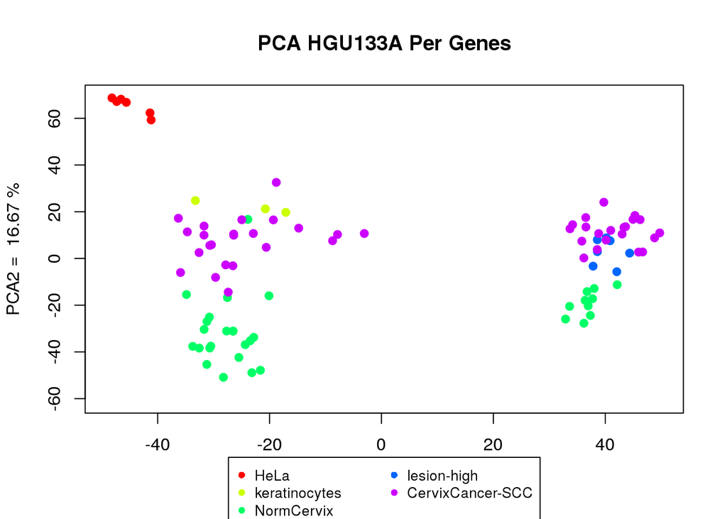

```r
#Plot the PCA and set the main title and labels
par( xpd=TRUE)
plot(NULL, main="PCA HGU133A Per Genes", xlab=paste("PCA1 = ", as.character(percentil[1]),"%"), ylab=paste("PCA2 = ", as.character(percentil[2]),"%"), xlim=xlims, ylim=ylims)

for(i in 1:length(interested)){
        datalist<-which(phenodata$samples %in% interested[i]);
        points(pca$x[datalist,1],pca$x[datalist,2], col=colors[i], pch=20, cex = 1.5)
}

legend("bottom",inset=c(0,-0.35),legend=interested, col=colors, pch=16, bg="#FFFFFF", ncol=2,cex=.85)
```

```r
#save the plot in two formats svg and pdf
dev.print(svg,"pca_per_genes.svg");
```

```r
dev.print(pdf,"pca_per_genes.pdf");
```

*Analisis of the results*

If we compare this PCA results we can say that all the PCAs corectly most of the data except the NormalCervix Samples and the Cervical Cancer samples.

We summarize the first two components in this table

[output not shown]

#### Heatmap Plots

A **heat map** is a graphical representation of data where the individual values contained in a matrix are represented as colors. Fractal maps and tree maps both often use a similar system of color-coding to represent the values taken by a variable in a hierarchy. The term is also used to mean its thematic application as a choropleth map.

```r
#Fit linear model for each gene given a series of arrays
library(limma)

library(gplots)

#SET THE COLORS FOR THE SAMPLES
color.clasification.map <- function(mol.biol) {
    colors_clasification[which(unique(phenodata$samples)==mol.biol)]
}


colors_clasification<-rainbow(length(unique(phenodata$samples)))

sampecolors <- unlist(lapply(phenodata$samples,"color.clasification.map"))
```

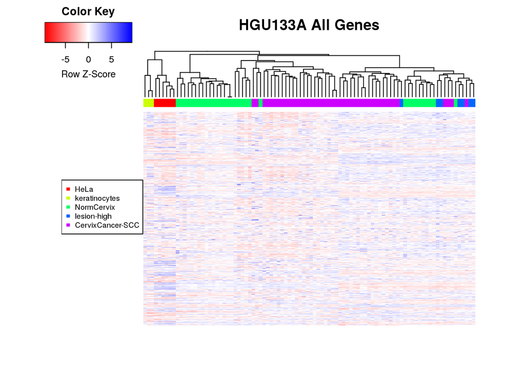

```r
rv = rowVars(exprs(gset))
select = order(rv, decreasing=TRUE)#[seq_len(500)]

expSetClasifications <- exprs(gset)[select,]

phenodata<-pData(gset)


heatmap.2(expSetClasifications[order(rowMeans(expSetClasifications[,phenodata$samples=="HaCaT"])),], col=redblue(75), scale="row", ColSideColors=sampecolors, main="HGU133A All Genes", key=TRUE, symkey=FALSE, density.info="none", trace="none", cexRow=0.8,labCol=NA,  dendrogram = "column",xaxt = "n", labRow=c(rep("",1000)))
legend(.0,.5,legend=unique(phenodata$samples), col=colors_clasification, pch=15, bg="#FFFFFF", cex = .6)
```

```r
dev.print(svg,"heatmap_all_genes.svg");
```

```r
dev.print(pdf,"heatmap_all_genes.pdf");
```

Finding differentially expressed probesets

Now we have a filtered dataset, we can send the information to limma for differential gene expression analysis. First of all we need to extract information about the samples:

```r
samples <- as.factor(phenodata$samples)
samples
```

```
##  [1] HeLa             keratinocytes    keratinocytes    NormCervix
##  [5] NormCervix       NormCervix       NormCervix       NormCervix
##  [9] NormCervix       NormCervix       NormCervix       NormCervix
## [13] NormCervix       lesion-high      lesion-high      lesion-high
## [17] lesion-high      lesion-high      lesion-high      lesion-high
## [21] CervixCancer-SCC CervixCancer-SCC CervixCancer-SCC CervixCancer-SCC
## [25] CervixCancer-SCC CervixCancer-SCC CervixCancer-SCC CervixCancer-SCC
## [29] CervixCancer-SCC CervixCancer-SCC CervixCancer-SCC CervixCancer-SCC
## [33] CervixCancer-SCC CervixCancer-SCC CervixCancer-SCC CervixCancer-SCC
## [37] CervixCancer-SCC CervixCancer-SCC CervixCancer-SCC CervixCancer-SCC
## [41] CervixCancer-SCC HeLa             HeLa             HeLa
## [45] HeLa             NormCervix       NormCervix       NormCervix
## [49] NormCervix       NormCervix       NormCervix       NormCervix
## [53] NormCervix       NormCervix       NormCervix       NormCervix
## [57] NormCervix       NormCervix       NormCervix       NormCervix
## [61] NormCervix       NormCervix       NormCervix       NormCervix
## [65] NormCervix       NormCervix       CervixCancer-SCC CervixCancer-SCC
## [69] CervixCancer-SCC CervixCancer-SCC CervixCancer-SCC CervixCancer-SCC
## [73] CervixCancer-SCC CervixCancer-SCC CervixCancer-SCC CervixCancer-SCC
## [77] CervixCancer-SCC CervixCancer-SCC CervixCancer-SCC CervixCancer-SCC
## [81] CervixCancer-SCC CervixCancer-SCC CervixCancer-SCC CervixCancer-SCC
## [85] CervixCancer-SCC CervixCancer-SCC CervixCancer-SCC CervixCancer-SCC
## [89] CervixCancer-SCC HeLa             NormCervix       keratinocytes
## Levels: CervixCancer-SCC HeLa keratinocytes lesion-high NormCervix
```

```r
design <- model.matrix(~0 + samples)


colnames(design) <-c("CervixCancerSCC","HeLa", "keratinocytes",  "lesionHigh", "NormCervix")
design
```

```
##    CervixCancerSCC HeLa keratinocytes lesionHigh NormCervix
## 1                0    1             0          0          0
## 2                0    0             1          0          0
## 3                0    0             1          0          0
## 4                0    0             0          0          1
## 5                0    0             0          0          1
## 6                0    0             0          0          1
## 7                0    0             0          0          1
## 8                0    0             0          0          1
## 9                0    0             0          0          1
## 10               0    0             0          0          1
## 11               0    0             0          0          1
## 12               0    0             0          0          1
## 13               0    0             0          0          1
## 14               0    0             0          1          0
```

[output cut: 83 more lines]

At this point we have normalised filtered data, and a description of the data and the samples and experimental design. This can be fed into limma for analysis.

```r
library(limma)

#Annotating the results with associated gene symbols
symbol_set <- eset[mean_max, ]
pData(symbol_set)<-pData(eset)
rownames(symbol_set)<-as.character(hgu133aSYMBOL)[mean_max]

# fit the linear model to the gene set
fit <- lmFit(exprs(symbol_set), design)
# set up a contrast matrix to compare tissues v cell line
contrast.matrix <- makeContrasts(Cancer_lesion= CervixCancerSCC - lesionHigh, Cancer_normal= CervixCancerSCC -  NormCervix,  lesion_normal= lesionHigh -  NormCervix, levels=design)
# check the contrast matrix
contrast.matrix
```

```
##                  Contrasts
## Levels            Cancer_lesion Cancer_normal lesion_normal
##   CervixCancerSCC             1             1             0
##   HeLa                        0             0             0
##   keratinocytes               0             0             0
##   lesionHigh                 -1             0             1
##   NormCervix                  0            -1            -1
```

```r
# Now the contrast matrix is combined with the per-probeset linear model fit.
fits <- contrasts.fit(fit, contrast.matrix)
ebFit <- eBayes(fits)
# return the top 30 results for any given contrast
# coef=1 is huvec_choroid, coef=2 is huvec_retina
topTable(ebFit, number=30, coef=1)
```

```
##               logFC   AveExpr          t      P.Value    adj.P.Val
## CFTR     -2.1715175  6.968640 -11.399100 4.134390e-19 5.141941e-15
## MSX1     -2.9125862  7.336162  -9.342537 7.097610e-15 4.413649e-11
## SLC34A2  -0.4795273  5.719145  -8.531418 3.409092e-13 1.413296e-09
## EMX2     -3.0392137  5.806137  -8.358619 7.758384e-13 2.412276e-09
## THSD4    -1.2399355  6.800389  -8.097691 2.677029e-12 6.658841e-09
## NUS1P3   -0.4246198  4.947547  -7.810297 1.041239e-11 2.158315e-08
## BHLHE41  -2.0373573  7.119185  -7.626113 2.476548e-11 4.400119e-08
## GSPT2    -1.4122078  6.216183  -7.463109 5.315106e-11 8.262997e-08
## NME5     -0.7478485  5.950033  -7.391272 7.434156e-11 1.027318e-07
## NLGN4X   -1.6934712  5.575779  -7.124967 2.562960e-10 3.187554e-07
## DEPTOR   -1.4738119  7.389234  -7.059474 3.469189e-10 3.922392e-07
## VWA5A    -1.3729000  8.888289  -6.568079 3.283141e-09 3.402702e-06
## CLDN10   -1.3041587  7.247191  -6.460228 5.342272e-09 5.110911e-06
## ZSCAN18  -1.4384009  7.612599  -6.420876 6.376707e-09 5.664793e-06
## UGT2B28  -0.6472447  6.908710  -6.353179 8.639197e-09 7.163046e-06
## PTCH1    -1.5542802  6.279445  -6.327154 9.706164e-09 7.544723e-06
## RNPS1     0.8253880 10.677133   6.259558 1.312431e-08 9.601588e-06
## CXCL5    -1.6098507  5.186731  -6.204161 1.679174e-08 1.101074e-05
## PLSCR1    1.3518591  9.631516   6.191856 1.773463e-08 1.101074e-05
## PLEKHS1  -1.0188832  4.801560  -6.183137 1.843417e-08 1.101074e-05
## FGF9     -1.7365129  6.712246  -6.177203 1.892581e-08 1.101074e-05
## FAM174B  -0.9530502  7.667059  -6.162504 2.019995e-08 1.101074e-05
## FCGBP    -2.9537754  9.192238  -6.160697 2.036238e-08 1.101074e-05
## U2SURP    1.2375178  9.307808   6.060037 3.176350e-08 1.646011e-05
## GPRC5C   -0.9149414  7.782069  -6.008545 3.983396e-08 1.981660e-05
## LDOC1    -1.2912089  8.877235  -5.971257 4.690909e-08 2.243878e-05
## CX3CR1   -1.4718140  6.996428  -5.899816 6.409501e-08 2.952406e-05
## MAP9     -0.2595866  4.625237  -5.882382 6.915306e-08 2.984963e-05
## ZNF112   -1.1991696  5.451197  -5.880896 6.960194e-08 2.984963e-05
## FAM189A2 -1.0555368  7.921026  -5.813443 9.329790e-08 3.867820e-05
##                  B
## CFTR     32.013031
## MSX1     22.978156
## SLC34A2  19.362537
## EMX2     18.593117
## THSD4    17.433456
## NUS1P3   16.160662
## BHLHE41  15.348298
## GSPT2    14.632052
## NME5     14.317306
## NLGN4X   13.156094
## DEPTOR   12.872001
## VWA5A    10.763078
## CLDN10   10.306331
## ZSCAN18  10.140292
## UGT2B28   9.855464
## PTCH1     9.746244
## RNPS1     9.463299
## CXCL5     9.232232
## PLSCR1    9.181008
## PLEKHS1   9.144736
## FGF9      9.120058
## FAM174B   9.058974
## FCGBP     9.051465
## U2SURP    8.634672
## GPRC5C    8.422492
## LDOC1     8.269293
## CX3CR1    7.976845
## MAP9      7.905696
## ZNF112    7.899636
## FAM189A2  7.625222
```

Now we create the volcano plot using this contrast models

```r
##Complete list of genes with p-values and fold change
##Coef=1, so we are just looking at huvec_choroid
gene_list <- topTable(ebFit, coef=1, number=1000000, sort.by="logFC")

##Highlight genes that have an absolute fold change > 2 and a padj.P.Val<0.05
gene_list$threshold = as.factor(abs(gene_list$logFC) > 2 & gene_list$adj.P.Val < 0.05)
```

Then we used ggplot2 for volcano plots

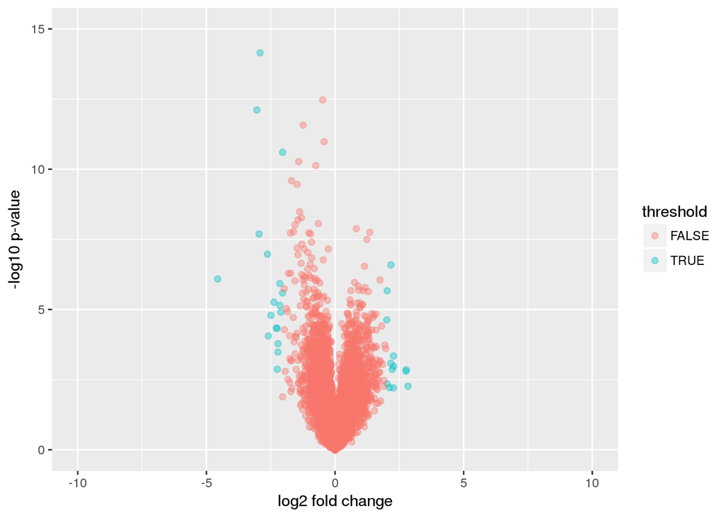

```r
require(ggplot2)

g = ggplot(data=gene_list, aes(x=logFC, y=-log10(P.Value), colour=threshold)) +
  geom_point(alpha=0.4, size=1.75) +
  xlim(c(-10, 10)) + ylim(c(0, 15)) +
  xlab("log2 fold change") + ylab("-log10 p-value")
g
```

```r
rv = rowVars(exprs(symbol_set))
select =rownames(gene_list[gene_list$threshold==TRUE,])

expSetClasifications <- exprs(symbol_set)[select,]
head(expSetClasifications)
```

```
##       GSM156764 GSM159933 GSM159934 GSM189384 GSM189385 GSM189386
## OLFM4  4.831198  4.983586  5.025547  5.426981 10.219251  5.115147
## EMX2   4.977898  5.313005  5.294597  6.379425  6.237483  5.070336
## FCGBP  7.364216  7.707184  7.859885  9.827508  8.983889 10.331457
## MSX1   7.488110  6.915115  6.983470  9.025478  7.087818  7.165199
## ID1    8.482253  7.215436  7.286801  5.873796  6.357962  5.917436
## KRT14  6.007174 14.384112 14.298676 12.928179 12.458424 12.924604
##       GSM189387 GSM189388 GSM189389 GSM189390 GSM189391 GSM189392
## OLFM4  7.416106  5.539348 10.729561  9.477437  6.088382 12.465231
## EMX2   5.578726  6.561422  5.239958  6.586241  5.144839  6.719764
## FCGBP 10.303390 10.887609 10.096936 11.521938  9.353775 11.233757
## MSX1   7.360249  8.989083  7.013512  8.711023  7.187295  7.646226
## ID1    5.874089  5.812028  5.811642  5.512763  5.727663  6.098048
## KRT14 12.879034 12.706919 12.086454 11.942254 12.755992 11.031711
##       GSM189393 GSM189394 GSM189395 GSM189396 GSM189397 GSM189398
## OLFM4  9.525530 11.356227 11.606654  5.237100 11.268910 11.593784
## EMX2   5.151154  9.338089  9.010991  7.246626  7.471539  9.729286
## FCGBP 10.027913 10.736142 12.964920 11.212688 12.263013 11.414098
## MSX1   7.199814 11.522073 10.355850  8.047100  7.955216 11.449143
## ID1    5.750763  5.821570  5.984008  6.018215  5.626947  6.007314
## KRT14 12.989696  7.997096  7.029784 11.959012  7.259951  6.836485
##       GSM189399 GSM189400 GSM189401 GSM189402 GSM189403 GSM189404
## OLFM4 12.232989 10.185285 11.908817  5.013359  5.303626  5.203027
## EMX2   8.605934  8.583444  5.951800  5.128994  5.394964  6.796477
## FCGBP 12.209640 12.839948  9.218391  8.944575  9.282261  8.743008
## MSX1   8.704546 10.700231  7.144409  6.937894  7.012943  7.140646
## ID1    5.567206  5.757372  5.809918  6.650795  6.311797  5.946020
## KRT14 10.074969  9.731005  6.505374 12.696132 12.964909 13.204262
##       GSM189405 GSM189406 GSM189407 GSM189408 GSM189409 GSM189410
## OLFM4  4.856383  4.937169  5.063381  4.816875  4.964548  5.074646
## EMX2   5.692630  5.034766  7.378425  5.217263  5.075092  6.181038
## FCGBP  8.524849  8.020287  9.605033  8.100024  8.410240  8.847240
## MSX1   7.467609  6.580200  7.558475  6.807093  6.720752  7.283996
## ID1    6.459381  5.996173  5.495950  6.028882  6.723134  5.687657
## KRT14  6.285974 12.599086 10.182215 12.803983 12.729271 12.982826
##       GSM189411 GSM189412 GSM189413 GSM189414 GSM189415 GSM189416
## OLFM4  4.921973  4.982805  4.832068  5.054190  5.269418  4.820338
## EMX2   5.003179  5.087684  5.326354  5.251035  5.563845  5.279574
## FCGBP  9.541337 10.465850 10.009112  9.864990  8.966928  9.382639
## MSX1   6.681690  7.411918  7.171115  7.165314  6.920335  7.085410
```

[output cut: 57 more lines]

```
## KRT14 13.698974 11.456495  5.741467  5.618282 13.011097 12.140070
##       GSM247883 GSM247884 GSM247885 GSM247886 GSM247887 GSM263955
## OLFM4  5.537879  4.761395  6.377066  5.446561  7.780689  4.789819
## EMX2   4.968530  4.965978  5.268936  5.291104  5.600052  5.094323
## FCGBP  9.470481  7.217512  8.945120 11.735324 12.699335  7.270027
## MSX1   6.386092  6.535286  6.541537  7.703391  7.635547  6.777686
## ID1   12.217641 12.171237 12.328240 11.053072 11.838231 10.305576
## KRT14 13.871009 13.718572 12.088017 13.237143 13.328050  5.611048
##        GSM44684 GSM656384
## OLFM4  8.412830  4.902920
## EMX2   9.571276  5.121699
## FCGBP  8.118465  6.971290
## MSX1   9.635450  6.176130
## ID1   11.416897  6.962051
## KRT14  6.472050 14.312676
```

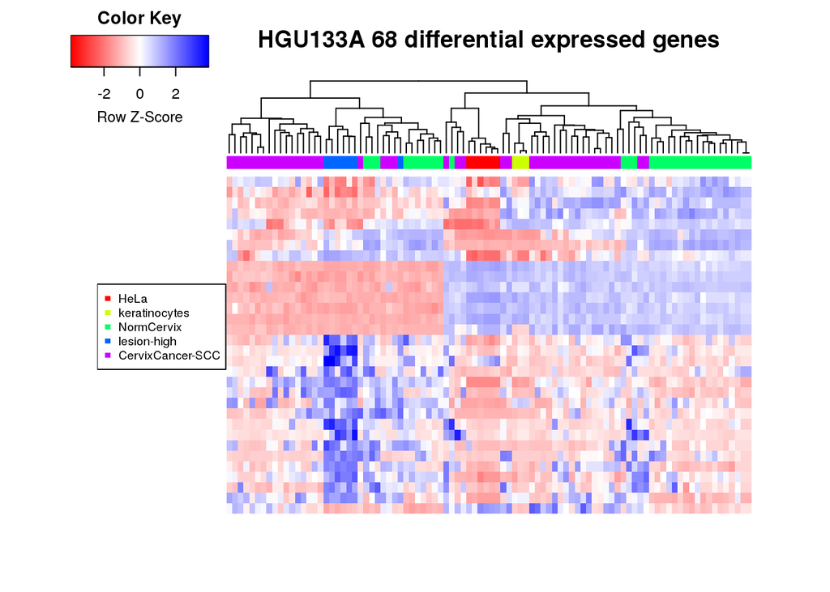

```r
phenodata<-pData(symbol_set)



heatmap.2(expSetClasifications, col=redblue(75), scale="row", ColSideColors=sampecolors, main="HGU133A 68 differential expressed genes", key=TRUE, symkey=FALSE, density.info="none", trace="none", cexRow=0.8,labCol=NA,  dendrogram = "column",xaxt = "n", labRow=c(rep("",1000)))
legend(.0,.5,legend=unique(phenodata$samples), col=colors_clasification, pch=15, bg="#FFFFFF", cex = .6)
```

```r
dev.print(svg,"heatmap_68_differential_expressed_genes.svg")
```

```r
dev.print(pdf,"heatmap_68_differential_expressed_genes.pdf")
```

NOTE: the probe_id of 214532_x_at have match with POU5F1B and POU5F1(oct4/3), also POU5F1P4 and POU5F1P3. (ref)[https://genecards.weizmann.ac.il/cgi-bin/geneannot/GA_search.pl?keyword_type=probe_set_id&target=genecards&keyword=214532_x_at&array=HG-U133] / (Fasta Seq GenBank: AF268615.1)[https://www.ncbi.nlm.nih.gov/nuccore/12382248?report=fasta] Sensitivity = 0.818, Specificity = 0.583.

```r
 probs_id<-as.list(hgu133aSYMBOL)[as.list(hgu133aSYMBOL) %in% c("CDKN2A", "PARP1",  "FOXC2", "PMS1", "SOX2","PAX6", "TGFB3", "WEE1", "ZFX", "NANOG", "BRIP1", "TP63", "KLF4", "C-MYC", "POU5F1","ZFP42","TDGF1", "STAT", "POU5F1B" )]

phenodata<-pData(eset)

sampecolors <- unlist(lapply(phenodata$samples[phenodata$samples %in% c("NormCervix","CervixCancer-SCC")],"color.clasification.map"))


expSetClasifications <- exprs(symbol_set)[rownames(exprs(symbol_set)) %in% c("CDKN2A", "PARP1",  "FOXC2", "PMS1", "SOX2","PAX6", "TGFB3", "WEE1", "ZFX", "NANOG", "BRIP1", "TP63", "KLF4", "C-MYC", "POU5F1","ZFP42","TDGF1", "STAT", "POU5F1B" ),phenodata$samples %in% c("NormCervix","CervixCancer-SCC")]

dev.off()
```

```r
heatmap.2(expSetClasifications, col=redblue(75), scale="row", ColSideColors=sampecolors, main=" ", key=TRUE, symkey=FALSE, density.info="none", trace="none", cexRow=1, labCol=NA,  dendrogram = "column", xaxt = "n", labRow=c(""))





expSetClasifications <- exprs(symbol_set)[rownames(exprs(symbol_set)) %in% c("PARP1" ),phenodata$samples %in% c("NormCervix","CervixCancer-SCC")]


expSetClasifications<-rbind(expSetClasifications,expSetClasifications)

z<-(expSetClasifications[1,]-mean(expSetClasifications[1,]))/sd(expSetClasifications[1,])
ord<-names(z[order(z)])

dev.off()
```

```r
svg("heatmap_68_differential_expressed_genes.svg")
heatmap.2(expSetClasifications[,ord], col=redblue(75), scale="row", ColSideColors=sampecolors, main=" ", key=TRUE, symkey=FALSE, density.info="none", trace="none", cexRow=1, labCol=NA,  dendrogram = "non", xaxt = "n", labRow=c(""), Rowv=FALSE, Colv=FALSE)

legend(.6,1,legend= c("CervixCancer-SCC","NormCervix"), col=colors_clasification, pch=15, bg="#FFFFFF", cex = .8)

dev.off()
```